# Summary

In this notebook, we inspect quality of weekly sale prediction models vs. that of daily prediction models.

We will look at two different metrics to measure quality of prediction:

- MEDian Absolute Error (MEDAE): for each observation (a pair [SKU config, date/week] in our case), we compute one error, which is the absolute of difference between predicted and ground truth values. Then we take the median of all the errors to obtain MEDAE.
- $R^2$ score (as documented in http://scikit-learn.org/stable/modules/model_evaluation.html#regression-metrics): measures how well future samples are likely to be predicted by the model. Best possible score is 1 and it can be negative (because the model can be arbitrarily worse). A constant model that always predicts the expected value of y, disregarding the input features, would get a $R^2$ score of 0.

**Pros and cons of each metrics:**

- MEDAE is straightforward, easy to understand. However, it is wrong to compare directly MEDAE of **daily** models with **weekly** models. The reason is that we are comparing two errors at different scales. Instead, the correct way is we first need to sum up absolute errors of a daily model by week to get the total error in each week. Then compare the median of aggregated errors with MEDAE of weekly models.
- In contrast, $R^2$ is not affected by the difference in scale. It means we can directly compare $R^2$ scores of the two models without having to do any aggregation. HOwever, we now have a metrics which is harder to interpret.

**Example of aggregation:**

```python
folder = zal_res + 'sg/sample/dayly/predict/'
fname = folder + 'backpacks_female_autumn_winter.csv'
daily_pred = pd.read_csv(fname, parse_dates=['date'])
week_err = cal_week_err(daily_pred)
```

```python
week_err.sort_values(['sku_config', 'week']).head()
```

|  | sku_config | week | err_lasso_regression | err_ridge_regression | err_boosted_regression_tree | err_random_forest | err_xgboost |
| --- | --- | --- | --- | --- | --- | --- | --- |
| 0 | 119C3ZZ4B1AF6BGS | 3 | 0.886036 | 0.961226 | 0.814478 | 0.769376 | 0.942543 |
| 1 | 119C3ZZ4B1AF6BGS | 4 | 3.134483 | 3.138267 | 3.000000 | 3.064440 | 3.000000 |
| 2 | 119C3ZZ4B1AF6BGS | 5 | 0.177247 | 0.187371 | 0.169295 | 0.061475 | 0.255080 |
| 3 | 119C3ZZ4B1AF6BGS | 6 | 3.080993 | 3.082995 | 3.081777 | 3.067676 | 3.106586 |
| 4 | 164DCAC8C99F17GS | 9 | 0.121651 | 0.114640 | 0.077749 | 0.069168 | 0.106586 |

```python
# libs
import pandas as pd
import numpy as np
import matplotlib.pyplot as plt
import seaborn as sns
import os

%matplotlib inline
```

```python
# dirs
zal_res = '/Users/gfg/projects/daas-markdown/res/Zalora/'
```

## Helpers

```python
def my_read_csv(path):
    try:
        df = pd.read_csv(path)
    except EmptyDataError:
        print('Empty data in file {}'.format(path))
        df = pd.DataFrame()
    return df

def join_csv(folder):
    frames = [my_read_csv(folder + fn) for fn in os.listdir(folder) if '.csv' in fn]
    return pd.concat(frames)
```

```python
def drop_train_errors(df):
    cols = [c for c in df.columns if 'train_' in c]
    return df.drop(cols, axis='columns')
```

```python
import sklearn.metrics as metrics
```

```python
def ls_groups(folder):
    return [fn.replace('.csv', '') for fn in os.listdir(folder) if '.csv' in fn]

def cal_r2(pred_dir, gr='backpacks_female_autumn_winter'):
    predict_df = pd.read_csv(pred_dir + '{}.csv'.format(gr))

    if not predict_df.empty:
        y_true = predict_df['n_sold']
        model_names = [cc.replace('predict_', '') for cc in predict_df.columns if 'predict_' in cc]

        def get_r2(m):
            y_pred = predict_df['predict_' + m]
            return metrics.r2_score(y_true, y_pred)

        r2_scores = [get_r2(m) for m in model_names]
        r2_df = pd.DataFrame({'group_id': gr, 'model': model_names, 'r2_score': r2_scores})

        return r2_df
    else:
        print('No prediction found for group {}, thus no r2 scores were computed'.format(gr))
        return pd.DataFrame()


def cal_goodness_of_fit(granularity='week', country='tw'):
    country_dir = zal_res + '{}/'.format(country)
    if country == 'tw' and granularity == 'day':
        pred_dir = country_dir + 'predict/'
    else:
        sample_dir = country_dir + 'sample/'
        pred_dir = sample_dir + '{}ly/predict/'.format(granularity)

    groups = ls_groups(pred_dir)
    print('computing goodness of fit for {} groups...'.format(len(groups)))

    frames = [ cal_r2(pred_dir, gr) for gr in groups]
    return pd.concat(frames)
```

```python
def get_best(sorted_df, n_model=5):
    n_row = sorted_df.shape[0]
    idx = np.arange(0, n_row, step=n_model)
    best = sorted_df.iloc[idx].copy()
    return best
```

```python
def plot_acc_gain(err_df, country, fig_dir):
    err_df['delta'].hist()
    plt.xlabel('Accuracy gain (%)'); plt.ylabel('# groups')
    n_group = len(err_df['group'])
    plt.title('Accuracy gain of weekly vs. daily model \n' +
              '({} data, {} groups)'.format(country.upper(), n_group))
    plt.savefig(fig_dir + 'acc_gain.pdf')
```

```python
def cal_week_err(daily_pred):
    daily_pred['week'] = daily_pred['date'].apply(lambda x: x.weekofyear)
    daily_pred['year'] = daily_pred['date'].apply(lambda x: x.year)

    models = [cc.replace('predict_', '') for cc in daily_pred.columns if 'predict_' in cc]
    # cal error for all models
    for m in models:
        daily_pred['err_{}'.format(m)] = np.abs(daily_pred['predict_{}'.format(m)] - daily_pred['n_sold'])

    # agg by (year, week) and SKU
    to_group = ['sku_config', 'year', 'week']
    err_cols = [cc for cc in daily_pred.columns if 'err_' in cc]
    cols = to_group + err_cols

    grouped = daily_pred[cols].groupby(to_group)
    total_err = grouped.agg(sum)
    total_err.reset_index(inplace=True)

    # find the smallest err
#     total_err['best'] = total_err.apply(lambda row: min(row[err_cols]), axis=1)
    return total_err
```

```python
def cal_medae(gr, count, day_pred_dir):
#     cal test MEDAEs at week level for models via aggreg daily error
    if (count % 30)==0:
        print('{} groups and counting...'.format(count))
    daily_pred = pd.read_csv(day_pred_dir + '{}.csv'.format(gr), parse_dates=['date'])
    week_err = cal_week_err(daily_pred)
    models = [cc.replace('predict_', '') for cc in daily_pred.columns if 'predict_' in cc]
    test_medae = [np.median(week_err['err_{}'.format(m)]) for m in models]

    return pd.DataFrame({'group': gr, 'model': models, 'test_medae_by_week': test_medae})
```

```python
# Aggreg daily error to get test MEDAEs at week level
def agg_daily_err(country='sg'):
#     sample_dir = zal_res + '{}/'.format(country) + 'sample/'
#     day_pred_dir = sample_dir + 'dayly/predict/'

    country_dir = zal_res + '{}'.format(country) + '/'
    day_pred_dir = country_dir + 'predict/'
    groups = ls_groups(day_pred_dir)
    frames = [ cal_medae(gr, i+1, day_pred_dir) for i, gr in enumerate(groups)]
    medae_by_daily_pred = pd.concat(frames)

    fname = country_dir + 'medae_by_daily_pred.csv'
    medae_by_daily_pred.to_csv(fname)
    print('dumped aggreg daily error to: {}'.format(fname))
    return medae_by_daily_pred
```

```python
def query_day_best(country='sg'):
    medae_by_daily_pred = agg_daily_err(country)
    medae_by_daily_pred.rename(columns={'model': 'daily_model'}, inplace=True)
    day_best = get_best(medae_by_daily_pred.sort_values(['group', 'test_medae_by_week']))
    return day_best
```

```python
def query_week_best(country='sg'):
    sample_dir = zal_res + '{}/'.format(country) + 'sample/'
    weekly_metric_dir = sample_dir + 'weekly/metrics/'
    weekly_err = join_csv(weekly_metric_dir)
    weekly_err.rename(columns={'model': 'weekly_model'}, inplace=True)
    week_best = get_best(weekly_err.sort_values(['group', 'test_medae']))
    return week_best
```

```python
def mk_fig_dir(country='sg'):
    fig_dir = zal_res + '{}/'.format(country) + 'plots/'
    if not os.path.exists(fig_dir):
        os.mkdir(fig_dir)

    return fig_dir
```

```python
def viz_r2(r2, country, fig_dir):
    r2['delta'].hist()
    plt.xlabel('Gain in R2-score'); plt.ylabel('# groups')
    n_group = len(r2['group_id'])
    plt.title('Accuracy gain of weekly vs. daily model \n' +
              '({} data, {} groups)'.format(country.upper(), n_group))

    plt.savefig(fig_dir + 'r2_gain.pdf')
```

# Prediction quality on TW data

```python
country = 'tw'
```

## R-squared score

```python
# daily models
daily_r2 = cal_goodness_of_fit(granularity='day', country='tw')
daily_r2 = daily_r2.sort_values(['group_id', 'r2_score'], ascending=False)
day_best = get_best(daily_r2)
day_best = day_best.rename(columns={'r2_score': 'day_r2_score', 'model': 'best_daily_model'})
```

```
computing goodness of fit for 142 groups...
```

```python
# weekly models
weekly_r2 = cal_goodness_of_fit(granularity='week', country='tw')
weekly_r2 = weekly_r2.sort_values(['group_id', 'r2_score'], ascending=False)
week_best = get_best(weekly_r2)
week_best.rename(columns={'r2_score': 'week_r2_score', 'model': 'best_weekly_model'}, inplace=True)
```

```
computing goodness of fit for 150 groups...
```

```python
r2 = pd.merge(week_best, day_best)
r2['delta'] = r2['week_r2_score'] - r2['day_r2_score']
r2['delta'].describe()
```

```
count    49.000000
mean      0.049124
std       0.281657
min      -0.803088
25%      -0.056078
50%       0.037067
75%       0.220024
max       0.747099
Name: delta, dtype: float64
```

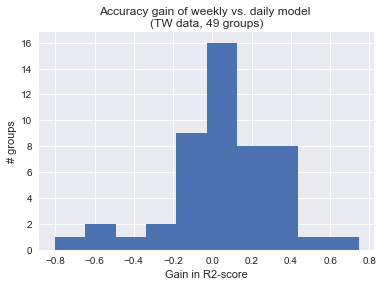

```python
fig_dir = mk_fig_dir(country)
r2['delta'].hist()
plt.xlabel('Gain in R2-score'); plt.ylabel('# groups')
n_group = len(r2['group_id'])
plt.title('Accuracy gain of weekly vs. daily model \n' +
          '({} data, {} groups)'.format(country.upper(), n_group))

plt.savefig(fig_dir + 'r2_gain.pdf')
```

## Accuracy

### Errors of daily predictions

```python
day_best = query_day_best(country='tw')
```

```
30 groups and counting...
60 groups and counting...
90 groups and counting...
120 groups and counting...
dumped aggreg daily error to: /Users/gfg/projects/daas-markdown/res/Zalora/tw/medae_by_daily_pred.csv
```

### Errors of weekly predictions

```python
week_best = query_week_best(country='tw')
```

```python
week_best.head()
```

|  | avg_records_per_config | group | weekly_model | n_config | n_samples | test_medae | test_medape | test_r2 | test_rmse | train_medae | train_medape | train_r2 | train_rmse |
| --- | --- | --- | --- | --- | --- | --- | --- | --- | --- | --- | --- | --- | --- |
| 0 | 16.0 | backpacks_female_autumn_winter | Random Forest | 302 | 4901 | 0.037810 | 3.561380e+06 | NaN | 0.428770 | 0.039853 | 3.780917e+06 | NaN | 0.417687 |
| 5 | 11.0 | backpacks_female_spring_summer | Random Forest | 479 | 5693 | 0.015135 | 1.513356e+06 | NaN | 0.338166 | 0.019528 | 1.513356e+06 | NaN | 0.299039 |
| 10 | 16.0 | backpacks_female_year_round | Random Forest | 29 | 491 | 0.033758 | 2.756660e+06 | NaN | 0.294614 | 0.032012 | 3.201104e+06 | NaN | 0.272574 |
| 15 | 14.0 | backpacks_male_autumn_winter | Random Forest | 213 | 3092 | 0.065939 | 6.593809e+06 | NaN | 0.957808 | 0.067072 | 6.593809e+06 | NaN | 0.789465 |
| 20 | 11.0 | backpacks_male_spring_summer | Random Forest | 248 | 2936 | 0.050858 | 5.085687e+06 | NaN | 0.321527 | 0.055419 | 5.378006e+06 | NaN | 0.428045 |

### Comparison

```python
cols = ['group', 'weekly_model', 'test_medae']
err_df = pd.merge(week_best[cols], day_best)

err_df['delta'] = (err_df['test_medae_by_week'] - err_df['test_medae'])
```

```python
err_df['delta'].describe()
```

```
count    49.000000
mean     -0.026064
std       0.039630
min      -0.201433
25%      -0.027505
50%      -0.015455
75%      -0.007417
max       0.028852
Name: delta, dtype: float64
```

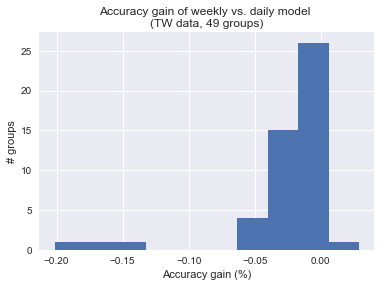

```python
fig_dir = mk_fig_dir(country='tw')
plot_acc_gain(err_df, country='tw', fig_dir=fig_dir)
```

```python
# proxy via multiply with 7
test_err_cols = ['test_medae', 'test_medape', 'test_rmse']

d_res = daily_best[test_err_cols].add_prefix('daily_')
d_res['group'] = daily_best['group']
d_res['7day_medae'] = d_res['daily_test_medae']*7

w_res = weekly_best[test_err_cols].add_prefix('weekly_')
w_res['group'] = weekly_best['group']

res = drop_train_errors(pd.merge(d_res, w_res))
res['acc_gain'] = 100 * (res['7day_medae'] - res['weekly_test_medae'])/res['7day_medae']
```

# Prediction quality on SG data

```python
country = 'sg'
```

## R-squared score

```python
# weekly models
weekly_r2 = cal_goodness_of_fit(granularity='week', country='sg')
weekly_r2 = weekly_r2.sort_values(['group_id', 'r2_score'], ascending=False)
week_best = get_best(weekly_r2)
week_best.rename(columns={'r2_score': 'week_r2_score', 'model': 'best_weekly_model'}, inplace=True)
```

```
computing goodness of fit for 150 groups...
```

```python
# daily models
daily_r2 = cal_goodness_of_fit(granularity='day', country='sg')
daily_r2 = daily_r2.sort_values(['group_id', 'r2_score'], ascending=False)
day_best = get_best(daily_r2)
day_best = day_best.rename(columns={'r2_score': 'day_r2_score', 'model': 'best_daily_model'})
```

```
computing goodness of fit for 150 groups...
```

```python
# Merge and compute gain
r2 = pd.merge(week_best, day_best)
r2['delta'] = r2['week_r2_score'] - r2['day_r2_score']
```

```python
r2['delta'].describe()
```

```
count    150.000000
mean      -0.457843
std        1.163621
min       -8.256454
25%       -0.565353
50%       -0.108920
75%        0.113900
max        0.731649
Name: delta, dtype: float64
```

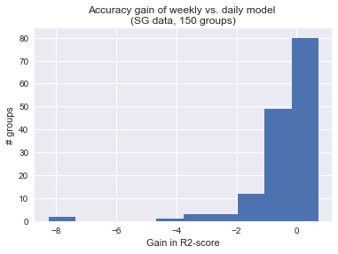

```python
fig_dir = mk_fig_dir(country)
viz_r2(r2, country, fig_dir)
```

## Accuracy

### Errors of daily predictions

```python
day_err = pd.read_csv('/Users/gfg/projects/daas-markdown/res/Zalora/sg/sample/medae_by_daily_pred.csv')
day_best = get_best(day_err)
# day_best = query_day_best(country='sg')
```

```python
day_best.shape
```

```
(150, 4)
```

### Errors of weekly predictions

```python
week_best = query_week_best(country='sg')
```

```python
week_best.shape
```

```
(150, 13)
```

### Comparison

```python
cols = ['group', 'weekly_model', 'test_medae']
err_df = pd.merge(week_best[cols], day_best)

err_df['delta'] = err_df['test_medae_by_week'] - err_df['test_medae']
err_df['delta'].describe()
```

```
count    150.000000
mean       0.226343
std        2.676927
min       -0.844482
25%       -0.097665
50%       -0.024955
75%        0.077371
max       32.698354
Name: delta, dtype: float64
```

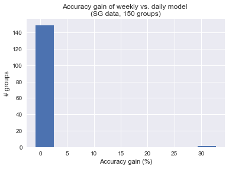

```python
fig_dir = mk_fig_dir(country='sg')
plot_acc_gain(err_df, country='sg', fig_dir=fig_dir)
```